# What’s Your Malfunction?

Victoria Zdanowicz

10/19/2021

# Challenge 1

> Write a simple R function, Z.prop.test(), that can perform one- or two-sample Z-tests for proportion data, using the following guidelines:
- p1 and n1 (no default) representing the estimated proportion and sample size (i.e., based on your sample data); p2 and n2 (both defaulting to NULL) that contain a second sample’s proportion and sample size data in the event of a two-sample test; p0 (no default) as the expected value for the population proportion; and alternative (default “two.sided”) and conf.level (default 0.95), to be used in the same way as in the function t.test()
- When conducting a two-sample test, it should be p1 that is tested as being smaller or larger than p2 when alternative=“less” or alternative=“greater”, the same as in the use of x and y in the function t.test().
- The function should perform a one-sample Z-test using p1, n1, and p0 if either p2 or n2 (or both) is NULL.
- The function should contain a check for the rules of thumb we have talked about (n∗p>5 and n∗(1−p)>5) to ensure the validity of assuming the normal distribution in both the one- and two-sample settings. If this is violated, the function should still complete but it should also print an appropriate warning message.
- The function should return a list containing the members Z (the test statistic), P (the appropriate p value), and CI (the two-sided CI with respect to “conf.level” around p1 in the case of a one-sample test and around p2-p1 in the case of a two-sample test). For all test alternatives (“two.sided”, “greater”, “less”), calculate symmetric CIs based on quantiles of the normal distribution rather than worrying about calculating single-limit confidence bounds.

In order to figure out how to create this function I opened up the source code for the prop.test() function. This was extremely helpful in following along the syntax necessary ( **if** , **else** ) and other words needed to organize how the function runs. I found a hard time finding a website that clearly outlined the proper order/syntax to follow when creating a function - I also couldn’t find that in any of the modules?

```r
library(dplyr)
library(curl)
```

```r
library(ggplot2)
```

z = (observed statistic - expected statistic) / standard error

my.func <- function(arg1, arg2, arg3, …) { return(output.object) }

z.prop.test() <- function(p1, n1, p2=NULL, n2=NULL, p0, alternative = “two.sided”, conf.level=0.95) p1<- sum(v1)/n1 n1 <- length(v1) p2 <- mean(v2) n2 <- length(v2) p0 = pi (expected proportion)

z1 <- (p1 - p0)/sqrt(1 - p0)/n1

pval <- 1 - pnorm(z1, lower.tail = TRUE) + pnorm(z1, lower.tail = FALSE) pval

if(!is.numeric(c(a1, r, n))) return(“The parameters must be numbers”)

if p2 and/or n2 = NULL -> one-sample z test

z = (p-p0) / √p0(1-p0)/n

*how to calculate CI for 2 sample? only see it from prop.test not written out in module*

## My function - z.prop.test()

```r
z.prop.test <- function(p1, n1, p2 = NULL, n2 = NULL, p0, alternative = "two-sided", conf.level = 0.95)
{

  if (is.null(p2)|is.null(n2)) {
      Z <- (p1 - p0) / sqrt(p0 * (1-p0)/n1)
      PVAL <- 1 - pnorm(Z, lower.tail = TRUE) + pnorm(Z, lower.tail = FALSE)
        if ((n1 * p0 < 5) | (n1 * (1 - p0) < 5 ))
        return(warning("check distribution, does not appear normal"))
          lower <- p1 - qnorm(0.975) * sqrt(p1 * (1 - p1)/n1)
          upper <- p1 + qnorm(0.975) * sqrt(p1 * (1 - p1)/n1)
          ci <- c(lower, upper)
          one.sample.prop <- list(z.test.statistic = as.numeric(Z), p.value = as.numeric(PVAL), conf.level = ci)

          return(one.sample.prop)
  }

  else  {
      pstar <- (p1 + p2)/(n1 + n2)
      Z <- (p2 - p1)/sqrt((pstar * (1 - pstar)) * (1/n1) + (1/n2))
      PVAL <- 1 - pnorm(Z, lower.tail = TRUE) + pnorm(Z, lower.tail = FALSE)
          if ((n1 * p0 < 5) | (n1 * (1 - p0) < 5 ) | (n2 * p0 < 5) | (n2 * (1 - p0) < 5)){
          warning("check distribution, does not appear normal")
}
            alpha = 1 - (conf.level/100)
            crit <- qnorm(1 - alpha/2)  # identify critical values
            test <- PVAL < -crit || PVAL > crit  # boolean test
            two.sample.prop <- list(z.test.statistic = as.numeric(Z), p.value = as.numeric(PVAL), conf.level = conf.level, critical.value = as.numeric(crit), test = test)

            return(two.sample.prop)
}}
```

## One-Sample Test

**Testing this function with sample data from module**

p1 = 0.6

n1 = 30L

```r
z.prop.test(0.6, 30, p0 = 0.8, alternative = "two-sided", conf.level = 0.95)
```

```
## $z.test.statistic
## [1] -2.738613
##
## $p.value
## [1] 1.99383
##
## $conf.level
## [1] 0.4246955 0.7753045
```

## Two-Sample Test

**Testing this function with sample data from module**

p1 = phat1

n1 = 25

p2 = phat2

n2 = 30

```r
z.prop.test(0.56, 25, 0.7, 30, p0 = 0, alternative = "two-sided", conf.level = 0.95)
```

```
## $z.test.statistic
## [1] 0.7567158
##
## $p.value
## [1] 0.4492201
##
## $conf.level
## [1] 0.95
##
## $critical.value
## [1] 0.01190677
##
## $test
## [1] TRUE
```

# Challenge 2

> The dataset from Kamilar and Cooper has in it a large number of variables related to life history and body size. For this exercise, the end aim is to fit a simple linear regression model to predict longevity (MaxLongevity_m) measured in months from species’ brain size (Brain_Size_Species_Mean) measured in grams. Do the following for both longevity~brain size and log(longevity)~log(brain size):
- Fit the regression model and, using {ggplot2}, produce a scatterplot with the fitted line superimposed upon the data. Append the the fitted model equation to your plot (HINT: use the function geom_text()).
- Identify and interpret the point estimate of the slope (β1), as well as the outcome of the test associated with the hypotheses H0: β1 = 0; HA: β1 ≠ 0. Also, find a 90 percent CI for the slope (β1) parameter. Using your model, add lines for the 90 percent confidence and prediction interval bands on the plot and add a legend to differentiate between the lines.
- Produce a point estimate and associated 90 percent PI for the longevity of a species whose brain weight is 800 gm. Do you trust the model to predict observations accurately for this value of the explanatory variable? Why or why not? Looking at your two models, which do you think is better? Why? *need to use predict() here !!*

pi <- predict(m, newdata = data.frame(weight = 150), interval = “prediction”, level = 0.95) # for a single value pi

```r
f <- curl("https://raw.githubusercontent.com/fuzzyatelin/fuzzyatelin.github.io/master/AN588_Fall21/KamilarAndCooperData.csv")
d <- read.csv(f, header = TRUE, stringsAsFactors = FALSE)
d <- na.omit(d)
longevity <- d$MaxLongevity_m
brainsize <- d$Brain_Size_Species_Mean
```

## Longevity~Brain Size

```r
beta1 <- cor(d$MaxLongevity_m, d$Brain_Size_Species_Mean) * sd(d$MaxLongevity_m)/sd(d$Brain_Size_Species_Mean)
beta1
```

```
## [1] 0.8789037
```

```r
beta0 <- mean(d$MaxLongevity_m) - beta1 * mean(d$Brain_Size_Species_Mean)
beta0
```

```
## [1] 307.7522
```

why do I keep getting NA for the equations above??? it is because I needed to omit missing values, check earlier chunk for na.omit

```r
m <- lm(longevity ~ brainsize, data = d)
m
```

```
##
## Call:
## lm(formula = longevity ~ brainsize, data = d)
##
## Coefficients:
## (Intercept)    brainsize
##    307.7522       0.8789
```

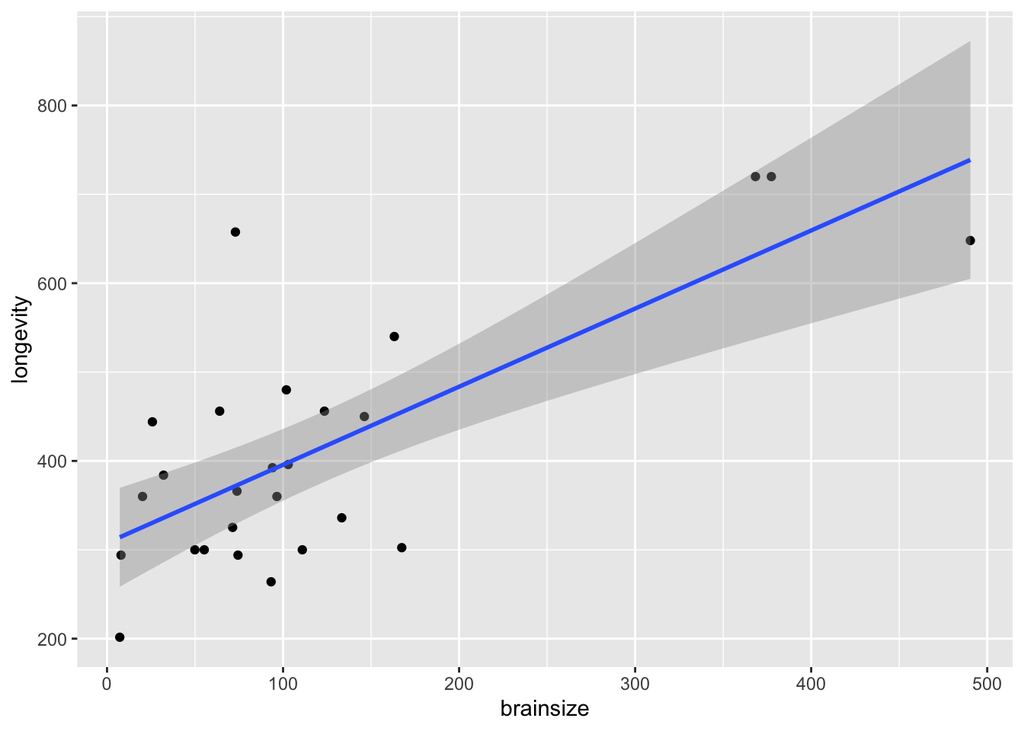

```r
g <- ggplot(data = d, aes(x = brainsize, y = longevity))
g <- g + geom_point()
g <- g + geom_smooth(method = "lm", formula = y ~ x)
g
```

```r
ci95 <- confint(m, level = 0.95)  # using the results of lm()
ci95
```

```
##                   2.5 %     97.5 %
## (Intercept) 250.2811660 365.223264
## brainsize     0.5337851   1.224022
```

```r
ci90 <- confint(m, level = 0.90)  # using the results of lm()
ci90
```

```
##                     5 %       95 %
## (Intercept) 260.1112167 355.393214
## brainsize     0.5928154   1.164992
```

fit the model by hand? with this?: y <- h - mean(h) x <- w - mean(w) z <- data.frame(cbind(x, y)) g <- ggplot(data = z, aes(x = x, y = y)) + geom_point() g ?

## Log(longevity) ~ Log(brain size)